# Homework 2: The Big Short

**This homework is due Friday February 26, 2016 at 5:00 PM. When complete, submit your code in the R Markdown file and the knitted HTML via GitHub.**

# Background

This homework is motivated by circumstances surrounding the [financial crisis of 2007-2008](https://en.wikipedia.org/wiki/Financial_crisis_of_2007%E2%80%9308). We titled the homework *The Big Short*, after the book on the same topic that was also recently made into a movie.

Part of what caused the financial crisis was that the risk of certain securities sold by financial institutions were underestimated. Specifically, the risk of mortgage-backed securities (MBS) and collateralized debt obligations (CDO), the price of which depends on homeowners making their monthly payments, was grossly underestimated. A combination of factors resulted in many more defaults than were expected. This resulted in a crash of the prices of these securities. As a consequence, banks lost so much money that they needed bailouts to avoid default.

Here we present a **very** simplified version of what happened with some of these securities. Hopefully it will help you understand how a wrong assumption about the statistical behavior of events can lead to substantial differences between what the model predicts and what actually happens. Specifically, we will see how using an independence assumption can result in misleading conclusions. Before we start with the specific application we ask you about a simple casino game.

# Problem 1

In the game of [roullete](https://en.wikipedia.org/wiki/Roulette) you can bet on several things including black or red. On this bet, if you win, you double your earnings. How does the casino make money on this then? If you look at the [possibilities](http://www.math.uah.edu/stat/games/Roulette.png) you realize that the chance of red or black are both slightly less than 1/2. There are two green spots, so the of landing on black (or red) is actually 18/38, or 9/19.

## Problem 1A

Let’s make a quick sampling model for this simple version of roulette. You are going to bet a dollar each time you play and always bet on black. Make a box model for this process using the `sample` function. Write a function `get_outcome` that takes as an argument the number of times you play $N$ and returns your earnings $S_N$.

```r
get_outcome<-function(n){
  x<-sample(c(-1,1),n,replace=TRUE,prob=c(10/19,9/19))
  sum(x)
}
```

## Problem 1B

Use Monte Carlo simulation to study the distribution of total earnings $S_N$ for $N=10,25,100,1000$. That is, study the distribution of earnings for different number of plays. What are the distributions of these two random variables? How do the expected values and standard errors change with $N$? Then do the same thing for the average winnings $S_N/N$. What result that you learned in class predicts this? First, we study the distribution of total earnings $S_N$.

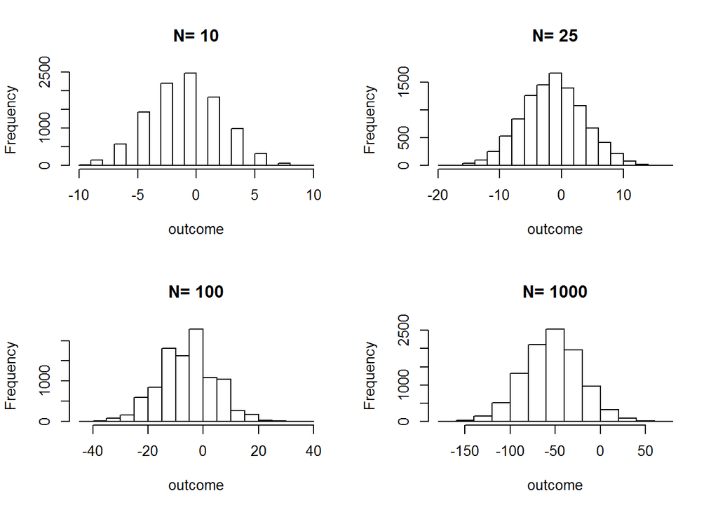

```r
N<-c(10,25,100,1000)
par(mfrow=c(2,2))
means<-{}
stds<-{}
for(i in N){
  B<-10000
  tab<-replicate(B,{
    get_outcome(i)
  })
  hist(tab, main=paste("N=",i),xlab="outcome")
  means<-c(means,mean(tab))
  stds<-c(stds,sd(tab))
}
```

```r
means
```

```
## [1]  -0.4848  -1.3596  -5.3438 -52.4590
```

```r
stds
```

```
## [1]  3.148644  4.973486  9.956973 31.391315
```

It seems that the expected value of $S_N$ decreases as $N$ increases and the standard errors of $S_N$ increases as $N$ increases.  
Then we study the distribution of the average earning $S_N/N$

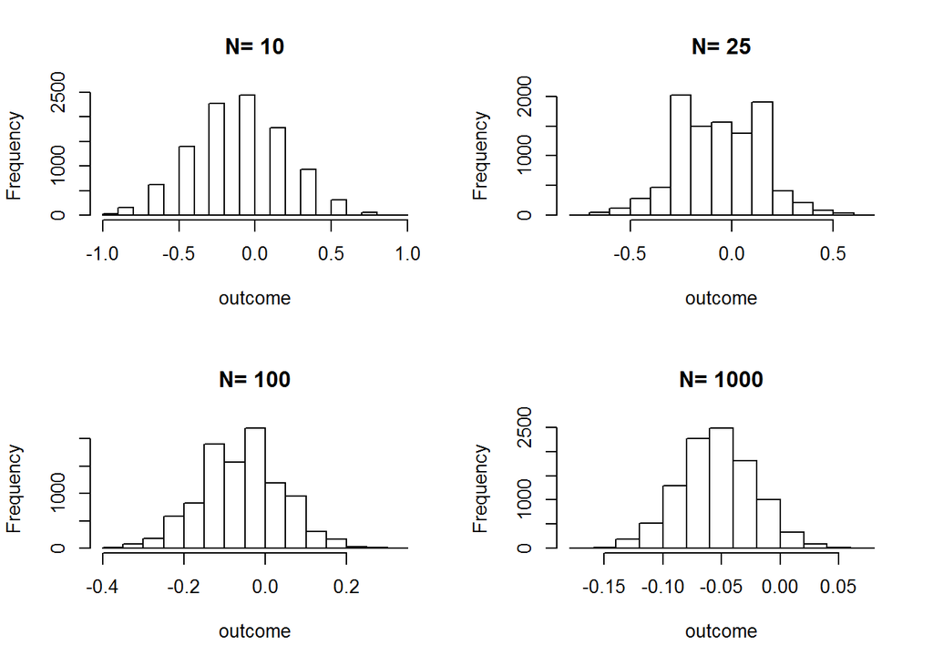

```r
par(mfrow=c(2,2))
meansn<-{}
stdsn<-{}
for(i in N){
  B<-10000
  tabsn<-replicate(B,{
    get_outcome(i)/i
  })
  hist(tabsn, main=paste("N=",i),xlab="outcome")
  meansn<-c(meansn,mean(tabsn))
  stdsn<-c(stdsn,sd(tabsn))
}
```

```r
meansn
```

```
## [1] -0.0560800 -0.0502800 -0.0537500 -0.0529072
```

```r
stdsn
```

```
## [1] 0.31636852 0.20241783 0.10012622 0.03159681
```

It seems that the expected value of $S_N/N$ remains the same as $N$ increases and the standard errors of $S_N/N$ decreases as $N$ increases.  
Law of Large Numbers predicts this.

## Problem 1C

What is the expected value of our sampling model? What is the standard deviation of our sampling model?

The expected value of our sampling model is
$$1\times \frac{9}{19}+(-1) \times \frac{10}{19}=-0.0526$$
The standard deviation of our sampling model is
$$2\times \sqrt{\frac{9}{19}\frac{10}{19}}=1.00$$

## Problem 1D

Use CLT to approximate the probability that the casino loses money when you play 25 times. Then use a Monte Carlo simulation to confirm.

First use CLT to approximate the probability.

```r
N<-25
mu<--1/19
sigma<-2*sqrt(9/19*10/19)
1-pnorm((0-mu)/(sigma/sqrt(N)))
```

```
## [1] 0.3960737
```

Then we use a Monte Carlo simulation to confirm.

```r
tab25<-replicate(B,{
    get_outcome(25)
  })
mean25<-mean(tab25)
std25<-sd(tab25)
1-pnorm((0-mean25)/std25)
```

```
## [1] 0.402101
```

We get very similar results at around 0.4.

## Problem 1E

In general, what is the probability that the casino loses money as a function of $N$? Make a plot for values ranging from 25 to 1,000. Why does the casino give you free drinks if you keep playing?

The probability that the casino losed money is
$$1-\Phi(-\sqrt{N}\frac{\mu}{\sigma})$$

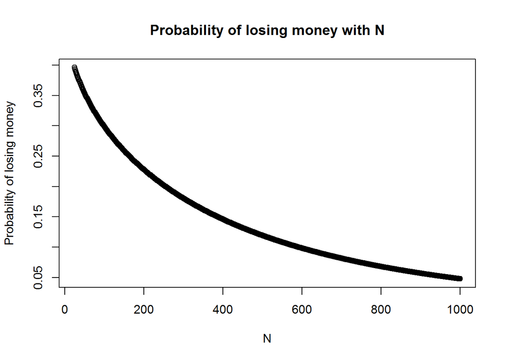

```r
par(mfrow=c(1,1))
Ns<-seq(from=25,to=1000,by=1)
ps<-{}
for(i in Ns){
  p=1-pnorm((0-mu)/(sigma/sqrt(i)))
  ps<-c(ps,p)
}
plot(Ns,ps,xlab="N",ylab="Probability of losing money",main="Probability of losing money with N")
```

Clearly, as n increases, the probability that the casino loses money decreases a lot. So the casino give us free drinks if we keep playing.

# Problem 2

You run a bank that has a history of identifying potential homeowners that can be trusted to make payments. In fact, historically, in a given year, only 2% of your customers default. You want to use stochastic models to get an idea of what interest rates you should charge to guarantee a profit this upcoming year.

## Problem 2A

Your bank gives out 1,000 loans this year. Create a sampling model and use the function `sample` to simulate the number of foreclosure in a year with the information that 2% of customers default. Also suppose your bank loses $120,000 on each foreclosure. Run the simulation for one year and report your loss.

```r
get_money<-function(n){
  x<-sample(c(0,1),n,replace=TRUE,prob=c(0.98,0.02))
  sum(x)
}
set.seed(1)
loss_in_one_year<--120000*get_money(1000)
loss_in_one_year
```

```
## [1] -2760000
```

As we can see, the loss is around $2760000.

## Problem 2B

Note that the loss you will incur is a random variable. Use Monte Carlo simulation to estimate the distribution of this random variable. Use summaries and visualization to describe your potential losses to your board of trustees.

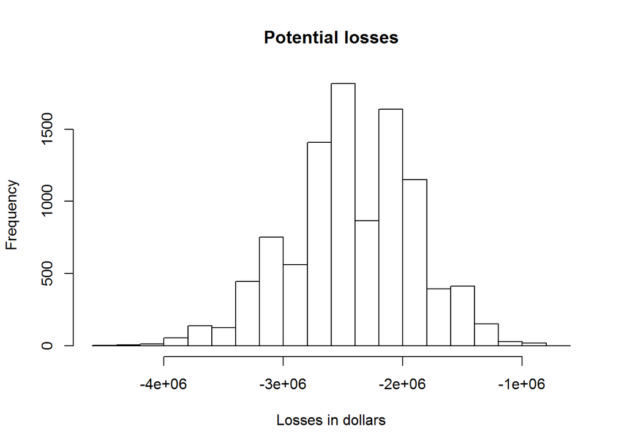

```r
set.seed(2)
tabmon<-replicate(B,{
    get_money(1000)*(-120000)
  })
hist(tabmon,main="Potential losses",xlab="Losses in dollars")
```

```r
summary(tabmon)
```

```
##     Min.  1st Qu.   Median     Mean  3rd Qu.     Max.
## -4560000 -2760000 -2400000 -2402000 -2040000  -720000
```

```r
sd(tabmon)
```

```
## [1] 532107.2
```

The average potential losses is about $2402000. And the distribution of potential losses is approximately normal.

## Problem 2C

The 1,000 loans you gave out were for $180,000. The way your bank can give out loans and not lose money is by charging an interest rate. If you charge an interest rate of, say, 2% you would earn $3,600 for each loan that doesn’t foreclose. At what percentage should you set the interest rate so that your expected profit totals $100,000. Hint: Create a sampling model with expected value 100 so that when multiplied by the 1,000 loans you get an expectation of $100,000. Corroborate your answer with a Monte Carlo simulation.

In order to get expected profit totals $100000,
$$180000\times rate\times 0.98 -120000\times 0.02=100$$
$$rate=0.014172$$

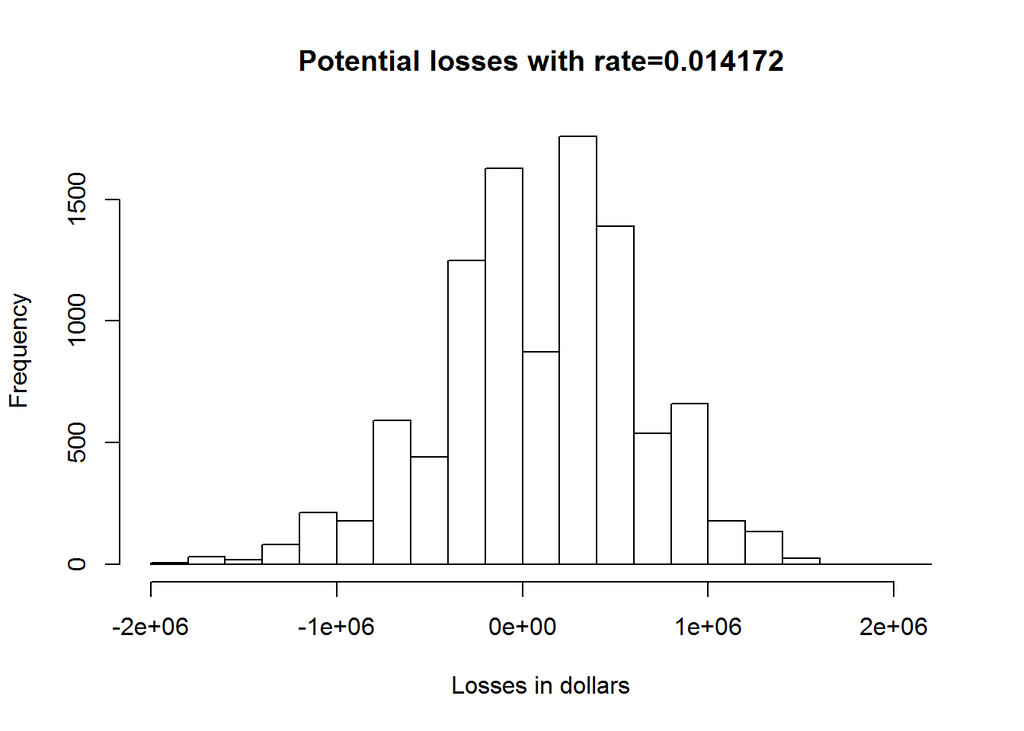

```r
rate<-0.014172
loan<-180000
get_moneyrate<-function(n){
  x<-sample(c(loan*rate,-120000),n,replace=TRUE,prob=c(0.98,0.02))
  sum(x)
}
tabmonrate<-replicate(B,{
    get_moneyrate(1000)
  })
hist(tabmonrate,main="Potential losses with rate=0.014172",xlab = "Losses in dollars")
```

```r
summary(tabmonrate)
```

```
##     Min.  1st Qu.   Median     Mean  3rd Qu.     Max.
## -1983000  -267700    99940    93650   467600  2061000
```

```r
sd(tabmonrate)
```

```
## [1] 542944.1
```

## Problem 2D

In problem 2C, you were able to set a very low interest rate. Your customers will be very happy and you are expected to earn $100,000 in profits. However, that is just an expectation. Our profit is a random variable. If instead of a profit your bank loses money, your bank defaults. Under the conditions of Problem 2C, what is the probability that your profit is less than 0?

First, we use CLT to calculate the probability that our profit is less than 0.

```r
mu<-100
sigma<-(loan*rate+120000)*sqrt(0.02*0.98)
pnorm((0-mu)/(sigma/sqrt(1000)))
```

```
## [1] 0.4268841
```

Then we use simulation.

```r
x<-as.numeric(tabmonrate<0)
mean(x)
```

```
## [1] 0.4439
```

## Problem 2E

Note that the probability of losing money is quite high. To what value would you have to raise interest rates in order to make the probability of losing money, and your bank and your job, as low as 0.001? What is the expected profit with this interest rate? Corroborate your answer with a Monte Carlo simulation.

Hint: Use the following short cut. If $p$ fraction of a box are $a$s and $(1-p)$ are $b$s, then the SD of the list is $\mid a-b \mid \sqrt{p(1-p)}$

First,we use CLT.

```r
qnorm(0.001)
```

```
## [1] -3.090232
```

$$\frac{(0.02\times 120000-0.98\times 180000\times rate)\times \sqrt(1000)}{(120000+180000\times rate)\sqrt{0.98\times 0.02}}=-3.09023$$
$$rate=0.023237$$
$$\mu=(0.98\times 180000\times rate-0.02\times 120000)\times 1000=1698900$$

So we should raise interest rate to 0.023237 and the expected profit is $1698900.

Then we use simulation

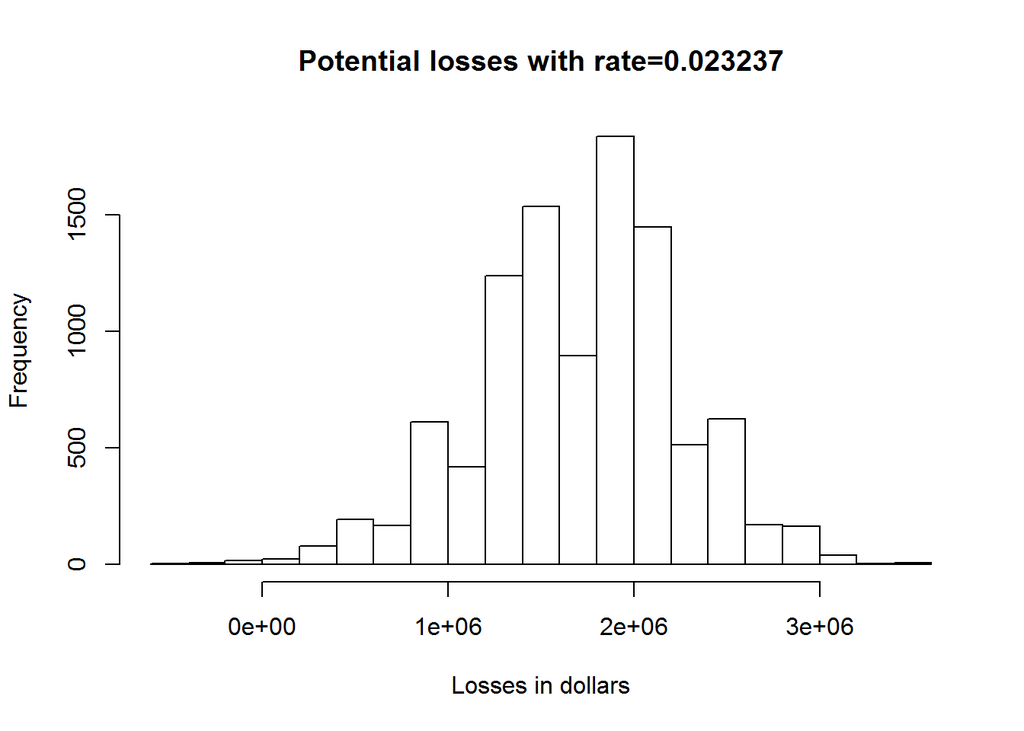

```r
newrate<-0.023237
loan<-180000
get_moneynewrate<-function(n){
  x<-sample(c(loan*newrate,-120000),n,replace=TRUE,prob=c(0.98,0.02))
  sum(x)
}
set.seed(3)
tabmonnewrate<-replicate(B,{
    get_moneynewrate(1000)
  })
hist(tabmonnewrate,main="Potential losses with rate=0.023237",xlab="Losses in dollars")
```

```r
summary(tabmonnewrate)
```

```
##    Min. 1st Qu.  Median    Mean 3rd Qu.    Max.
## -536300 1326000 1699000 1704000 2072000 3562000
```

```r
sd(tabmonnewrate)
```

```
## [1] 548512
```

```r
x<-as.numeric(tabmonnewrate<0)
mean(x)
```

```
## [1] 0.0026
```

The Monte Carlo simulation gives a slightly higher probability probability at around 0.0026.

## Problem 2F

Note that the Monte Carlo simulation gave a slightly higher probability than 0.001. What is a possible reason for this? Hint: See if the disparity is smaller for larger values of $p$. Also check for probabilities larger than 0.001. Recall we made an assumption when we calculated the interest rate.

The possible reason for this may be the distribution of sample does not strictly follow a normal distribution when p is low and close to 0. So using normal distribution to approximate will cause error. In order to confirm this, we use a larger p. Let p=0.1

$$\frac{(0.1\times 120000-0.9\times 180000\times rate)\times \sqrt(1000)}{(120000+180000\times rate)\sqrt{0.9\times 0.1}}=-3.09023$$
$$rate=0.098405$$

Then we use Monte Carlo to confirm this.

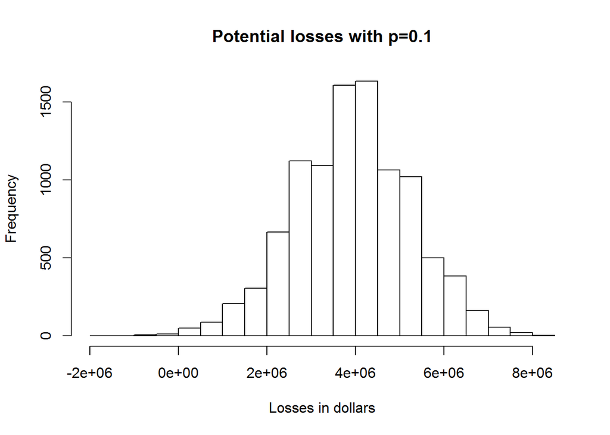

```r
newrate<-0.098405
loan<-180000
get_moneynewrate<-function(n){
  x<-sample(c(loan*newrate,-120000),n,replace=TRUE,prob=c(0.9,0.1))
  sum(x)
}
set.seed(1)
tabmonnewrate<-replicate(B,{
    get_moneynewrate(1000)
  })
hist(tabmonnewrate,main="Potential losses with p=0.1",xlab="Losses in dollars")
```

```r
summary(tabmonnewrate)
```

```
##     Min.  1st Qu.   Median     Mean  3rd Qu.     Max.
## -1567000  3115000  3942000  3939000  4768000  8486000
```

```r
sd(tabmonnewrate)
```

```
## [1] 1317631
```

```r
x<-as.numeric(tabmonnewrate<0)
mean(x)
```

```
## [1] 0.0019
```

We can find the simulation result is closer to 0.001 compared to the previous one.

## Problem 3

We were able to set an interest rate of about 2% that guaranteed a very low probability of having a loss. Furthermore, the expected average was over $1 million. Now other financial companies noticed the success of our business. They also noted that if we increase the number of loans we give, our profits increase. However, the pool of reliable borrowers was limited. So these other companies decided to give loans to less reliable borrowers but at a higher rate.

## Problem 3A

The pool of borrowers they found had a much higher default rate, estimated to be $p=0.05$. What interest rate would give these companies the same expected profit as your bank (Answer to 2E)?

First, we calculated the interest rate

$$\mu=(0.95\times 180000\times rate-0.05\times 120000)\times 1000=1698900$$
$$rate=0.045$$
So we need to raise the interest rate to 0.045 to give these companies the same expected profit as my bank.

```r
rate3<-0.045
loan<-180000
get_moneyrate3<-function(n){
  x<-sample(c(loan*rate3,-120000),n,replace=TRUE,prob=c(0.95,0.05))
  sum(x)
}
tabmonrate3<-replicate(B,{
    get_moneyrate3(1000)
  })
summary(tabmonrate3)
```

```
##     Min.  1st Qu.   Median     Mean  3rd Qu.     Max.
## -1636000  1183000  1695000  1693000  2336000  4898000
```

The simulation result confirms this.

## Problem 3B

At the interest rate calculated in 3A what is the probability of negative profits? Use both the normal approximation and then confirm with a Monte Carlo simulation.

Fisrt, we use the normal approximation.

```r
mu<-1698.9
sigma<-(loan*rate3+120000)*sqrt(0.05*0.95)
pnorm((0-mu)/(sigma/sqrt(1000)))
```

```
## [1] 0.02715874
```

Then we confirm with a Monte Carlo simulation.

```r
x<-as.numeric(tabmonrate3<0)
mean(x)
```

```
## [1] 0.0295
```

We get very similar results at around 0.028

## Problem 3C

Note that the probability is much higher now. This is because the standard deviation grew. The companies giving out the loans did not want to raise interest rates much more since it would drive away clients. Instead they used a statistical approach. They increased $N$. How large does $N$ need to be for this probability to be 0.001? Use the central limit approximation and then confirm with a Monte Carlo simulation.

We use the central limit approximation first.
$$\frac{(0.05\times 120000-0.95\times 180000\times 0.045)\times \sqrt(N)}{(120000+180000\times 0.045)\sqrt{0.95\times 0.05}}=-3.09023$$
$$N=2591$$
Then we use a Monte Carlo simulation.

```r
tabmonrate3_N<-replicate(B,{
    get_moneyrate3(2591)
  })
summary(tabmonrate3_N)
```

```
##     Min.  1st Qu.   Median     Mean  3rd Qu.     Max.
## -1046000  3437000  4462000  4394000  5359000  9202000
```

```r
x<-as.numeric(tabmonrate3_N<0)
mean(x)
```

```
## [1] 0.0021
```

So by doubling the number of loans we were able to reduce our risk! Now, for this to work, all the assumptions in our model need to be approximately correct, including the assumption that the probability of default was **independent**. This turned out to be false and the main reason for the under estimation of risk.

## Problem 3D

Define the following matrix of outcomes for two borrowers using our previous box model:

```r
loan <- 180000
loss_per_foreclosure <- 120000
p2 <- 0.05
interest_rate2 <- 0.05
B <- 10^5
outcomes1 <- replicate(B,{
  sample( c(-loss_per_foreclosure, interest_rate2*loan ), 2, replace=TRUE, prob=c(p2, 1-p2))
})
```

We can confirm independence by computing the probability of default for the second conditioned on the first defaulting:

```r
sum( outcomes1[1,] < 0 & outcomes1[2,]<0)/sum(outcomes1[1,]<0)
```

```
## [1] 0.04768473
```

This quantity is about the same as the probability of default $0.05$.

Now we create a new model. Before generating each set of defaults, we assume that a random event occurred that makes all default probabilities go up or go down by 4 points. We could see how this would happen if, for example, demand for houses decreases and all house prices drop.

```r
B <- 10^5
outcomes2 <- replicate(B,{
  add <- sample( c(-0.04,0.04), 1)
  sample( c(-loss_per_foreclosure, interest_rate2*loan ), 2, replace=TRUE, prob=c(p2+add, 1-(p2+add)))
})
```

Note that the outcomes are no longer independent as demonstrated by this result not being equal to 0.05

```r
sum( outcomes2[1,] < 0 & outcomes2[2,]<0)/sum(outcomes2[1,]<0)
```

```
## [1] 0.07635122
```

Generate a simulation with correlated outcomes such as those above. This time use the interest rate calculated in 3A. What is the expected earnings under this model compared to the previous? What is the probability of losing $1 million compared to the previous? What is the probability of losing $10 million compared to the previous?

To compare to the previous, we calculate the expected earnings, probability of losing $1 million and probability of losing $10 million in the previous model.

```r
interest_rateold<-0.045
outcomes1 <- replicate(B,{
  sum(sample( c(-loss_per_foreclosure, interest_rateold*loan ), 2591, replace=TRUE, prob=c(p2, 1-p2)))
})
summary(outcomes1)
```

```
##     Min.  1st Qu.   Median     Mean  3rd Qu.     Max.
## -2071000  3437000  4462000  4385000  5359000 10230000
```

```r
mean(as.numeric(outcomes1<(-1000000)))
```

```
## [1] 0.00017
```

```r
mean(as.numeric(outcomes1<(-10000000)))
```

```
## [1] 0
```

Then we calculate the expected earnings, probability of losing $1 million and probability of losing $10 million in the new model.

```r
outcomes2 <- replicate(B,{
  add <- sample( c(-0.04,0.04), 1)
  sum(sample( c(-loss_per_foreclosure, interest_rateold*loan ), 2591, replace=TRUE, prob=c(p2+add, 1-(p2+add))))
})
summary(outcomes2)
```

```
##      Min.   1st Qu.    Median      Mean   3rd Qu.      Max.
## -16420000  -8860000  15610000   4420000  17660000  20220000
```

```r
mean(as.numeric(outcomes2<(-1000000)))
```

```
## [1] 0.49896
```

```r
mean(as.numeric(outcomes2<(-10000000)))
```

```
## [1] 0.14085
```

As we can see, though the expected value is similar, the probability of losing $1 million and $10 million largely increases.

## Problem 4

Read [this wikipedia page](https://en.wikipedia.org/wiki/Financial_crisis_of_2007%E2%80%9308) about the financial crisis. Write a paragraph describing how what you learned in this homework can help explain the conditions that led to the crisis.